# Assignment4

## Assignment 2

#### Kevin Francis

Develop a hypothetical set of sample training data or collect/produce a sample set of training data of a supervised learning problem that can be classified using a nonlinear SVM. In a simulation study, show how you will classify the dataset using a nonlinear SVM. Then, use an appropriate Kernel trick to change the nonlinear SVM to a linear SVM. Show the detailed work including the programming code and the simulation results (figures/plots).

```python
#Importing needed libraries
import numpy as np
import matplotlib.pyplot as plt
import pandas as pd
import seaborn as sns; sns.set(style = 'whitegrid')
from sklearn import svm, datasets
%matplotlib inline
```

First, lets generate some data that is not linearly separable. Below is a plot to see what the data looks like.

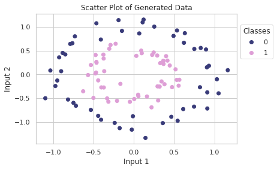

```python
# Generating grouped data
x, y = datasets.make_circles(n_samples=100, random_state=0, factor=0.5, noise=.1)
# Splitting the training and testing data
half = int(len(x) / 2)
train_x = x[:half]
test_x = x[half:]
train_y = y[:half]
test_y = y[half:]
# Creating a scatter plot to look at all of the the initial data
fig, ax = plt.subplots()
scatter = ax.scatter(x[:, 0], x[:, 1], c = y, cmap = 'tab20b')
ax.set(xlabel='Input 1', ylabel='Input 2', title = 'Scatter Plot of Generated Data')
ax.legend(*scatter.legend_elements(), loc="lower left", title="Classes", bbox_to_anchor=(1, .63));
```

Now lets train a SVM model. This is done using scikit-learn, the default kernel is a Radial Basis Function (RBF). am using a RBF kernel because the data is not linearly separable. Below the kernel is defined.

$\phi(r) = e^{-(\gamma r)^2}$,

where $r = ||x-x'||$

```python
# Training the SVM model and looking at the accuracy on the test data
svm_model = svm.SVC(kernel = 'rbf')
svm_model.fit(train_x, train_y)
svm_model.score(test_x, test_y)
```

```
0.96
```

Above is the accuracy for how the model performed on the test dataset. Using a RBF kernel, 96% accuracy was achieved.

```python
# Plot was found on the scikitlearn documentation
# step size in the mesh
h = .02
# Plot the decision boundary. For that, we will assign a color to each
# point in the mesh [x_min, x_max] x [y_min, y_max].
x_min, x_max = x[:, 0].min() - 1, x[:, 0].max() + 1
y_min, y_max = x[:, 1].min() - 1, x[:, 1].max() + 1
xx, yy = np.meshgrid(np.arange(x_min, x_max, h), np.arange(y_min, y_max, h))
# Using the trained model to predict all of the points in the mesh
Z = svm_model.predict(np.c_[xx.ravel(), yy.ravel()])
Z = Z.reshape(xx.shape)
# Put the result into a color plot
```

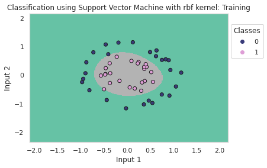

```python
fig, ax = plt.subplots()
ax.pcolormesh(xx, yy, Z, cmap = 'Set2', shading = 'auto')
# Plot the training data
scatter = ax.scatter(train_x[:, 0], train_x[:, 1], c = train_y, cmap = 'tab20b', edgecolors = 'k')
ax.set(xlabel='Input 1', ylabel='Input 2', title = 'Classification using Support Vector Machine with rbf kernel: Training')
ax.legend(*scatter.legend_elements(), loc = "lower left", title = "Classes", bbox_to_anchor = (1, .63));
```

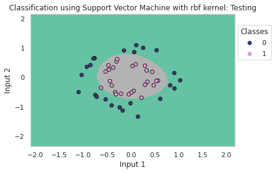

```python
fig, ax = plt.subplots()
ax.pcolormesh(xx, yy, Z, cmap = 'Set2', shading = 'auto')
# Plot the training data
scatter = ax.scatter(test_x[:, 0], test_x[:, 1], c = test_y, cmap = 'tab20b', edgecolors = 'k')
ax.set(xlabel='Input 1', ylabel='Input 2', title = 'Classification using Support Vector Machine with rbf kernel: Testing')
ax.legend(*scatter.legend_elements(), loc = "lower left", title = "Classes", bbox_to_anchor = (1, .63));
```

Above are some plots to visualize the svm classification regions.

Where x and y are a single point from input 1 and input 2.

Below is the transformation of the data.

```python
train_x = train_x.tolist()
for i in train_x:
    i.append(np.absolute(i[0]**2 + i[1]**2))
train_x = np.array(train_x)

test_x = test_x.tolist()
for i in test_x:
    i.append(np.absolute(i[0]**2 + i[1]**2))
test_x = np.array(test_x)
```

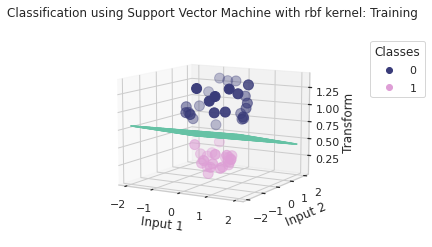

```python
# Training the new 3D model
model = svm.SVC(kernel='linear')
clf = model.fit(train_x, train_y)


# The equation of the separating plane is given by all x so that np.dot(svc.coef_[0], x) + b = 0.
# Solve for w3 (z)
z = lambda x,y: (-clf.intercept_[0]-clf.coef_[0][0]*x -clf.coef_[0][1]*y) / clf.coef_[0][2]

tmp = np.linspace(-2,2,30)
x,y = np.meshgrid(tmp,tmp)

fig = plt.figure()
ax  = fig.add_subplot(111, projection='3d')
#ax.set(zlim=(0,3))
ax.scatter(train_x[:, 0], train_x[:, 1], train_x[:, 2], c=train_y, cmap = 'tab20b', s = 100);
ax.plot_wireframe(x, y, z(x,y), color='#66C2A5')
ax.set(xlabel='Input 1', ylabel='Input 2', zlabel='Transform', title = 'Classification using Support Vector Machine with rbf kernel: Training')
ax.legend(*scatter.legend_elements(), loc = "lower left", title = "Classes", bbox_to_anchor = (1.2, .63))
ax.view_init(10, 300);
```

```python
model.score(test_x, test_y)
```

```
1.0
```

As we can see the accuracy has improved to 100%, and the data is now linearly separable. The two classifications can now be separated by a 2D plane.

Finally, a plot to see the classification of the testing data.

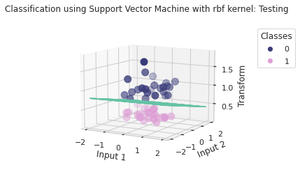

```python
fig = plt.figure()
ax  = fig.add_subplot(111, projection='3d')
#ax.set(zlim=(0,3))
ax.scatter(train_x[:, 0], test_x[:, 1], test_x[:, 2], c=test_y, cmap = 'tab20b', s = 100);
ax.plot_wireframe(x, y, z(x,y), color='#66C2A5')
ax.set(xlabel='Input 1', ylabel='Input 2', zlabel='Transform', title = 'Classification using Support Vector Machine with rbf kernel: Testing')
ax.legend(*scatter.legend_elements(), loc = "lower left", title = "Classes", bbox_to_anchor = (1.2, .63))
ax.view_init(10, 300);
```